# HW-Lego by Yiyong Huang

```r
library(tidyverse)
library(dsbox)
```

**Question 1** What are the three most common first names of purchasers?

```r
lego_sales %>% group_by(first_name) %>% count(first_name) %>%
  arrange(desc(n)) %>% head(5)
```

| first_name | n |
| --- | --- |
| Jackson | 13 |
| Jacob | 11 |
| Joseph | 11 |
| Michael | 10 |
| Audrey | 8 |

Answer: The three most common first names of purhasers are Jackson, Jacob and Joseph.

**Question 2** What are the three most common themes of Lego sets purchased?

```r
lego_sales %>% group_by(theme) %>% count(theme) %>% arrange(desc(n)) %>% head(5)
```

| theme | n |
| --- | --- |
| Star Wars | 75 |
| Nexo Knights | 64 |
| Gear | 55 |
| Mixels | 55 |
| City | 45 |

Answer: The three most common themes of Lego sets purchased are “Star Wars”, “Nexo Knights” and “Gear”.

**Question 3** Among the most common theme of Lego sets purchased, what is the most common subtheme?

```r
lego_sales %>% filter(theme=="Star Wars") %>%
  group_by(subtheme) %>% count(subtheme) %>%
  arrange(desc(n)) %>% head(3)
```

| subtheme | n |
| --- | --- |
| The Force Awakens | 15 |
| Buildable Figures | 11 |
| Episode V | 10 |

Answer: Among the most common theme of Lego sets purchased, the most common subtheme is “The Force Awakens”.

**Question 4** Create a new variable called age_group and group the ages into the following categories: “18 and under”, “19 - 25”, “26 - 35”, “36 - 50”, “51 and over”.

```r
lego_agegroup <- mutate(lego_sales, age_group =
                          case_when(
                            age <= 18 ~ "18 and under",
                            age <= 25 ~ "19 - 25",
                            age <= 35 ~ "26 - 35",
                            age <= 50 ~ "36 - 50",
                            TRUE ~ "51 and over"
                          ))
```

**Question 5** Which age group has purchased the highest number of Lego sets.

```r
lego_agegroup %>% group_by(age_group) %>% count(age_group, wt = quantity) %>%
  arrange(desc(n))
```

| age_group | n |
| --- | --- |
| 36 - 50 | 313 |
| 26 - 35 | 267 |
| 19 - 25 | 174 |
| 51 and over | 92 |
| 18 and under | 45 |

Answer: The age group of 36 - 50 has purchased the highest number of Lego sets.

**Question 6** Which age group has spent the most money on Legos?

```r
lego_agegroup %>% group_by(age_group) %>%
  count(age_group, wt = us_price * quantity) %>%
  arrange(desc(n))
```

| age_group | n |
| --- | --- |
| 36 - 50 | 9532.87 |
| 26 - 35 | 7576.33 |
| 19 - 25 | 4939.26 |
| 51 and over | 2475.08 |
| 18 and under | 948.55 |

The age group of 36 - 50 has spent the most money on Legos.

**Question 7** Which Lego theme has made the most money for Lego?

```r
lego_sales %>% group_by(theme) %>% count(theme, wt = us_price * quantity) %>%
  arrange(desc(n)) %>% head(3)
```

| theme | n |
| --- | --- |
| Star Wars | 4447.83 |
| Ninjago | 2279.41 |
| City | 2211.35 |

The Lego theme “Star Wars” has made the most money for lego.

**Question 8** Which area code has spent the most money on Legos? In the US the area code is the first 3 digits of a phone number.

```r
lego_sales %>% mutate(area = str_sub(phone_number, 1, 3)) %>%
  group_by(area) %>% count(area, wt = us_price * quantity) %>%
  arrange(desc(n)) %>% head(3)
```

| area | n |
| --- | --- |
| NA | 3992.64 |
| 956 | 719.96 |
| 973 | 684.91 |

Answer: The area code 956 has spent the most money on Legos.

**Question 9** Come up with a question you want to answer using these data, and write it down. Then, create a data visualization that answers the question, and explain how your visualization answers the question.

```r
lego_sales %>% group_by(us_price) %>% count(us_price) %>% arrange(desc(n))
```

| us_price | n |
| --- | --- |
| 9.99 | 108 |
| 19.99 | 79 |
| 4.99 | 69 |
| 29.99 | 68 |
| 14.99 | 46 |
| 24.99 | 39 |
| 49.99 | 37 |
| 39.99 | 30 |
| 5.99 | 23 |
| 12.99 | 23 |

[output cut: 16 more lines]

Answer: A question I want to answer using these data is: Which price of Lego sets purchased is most popular?

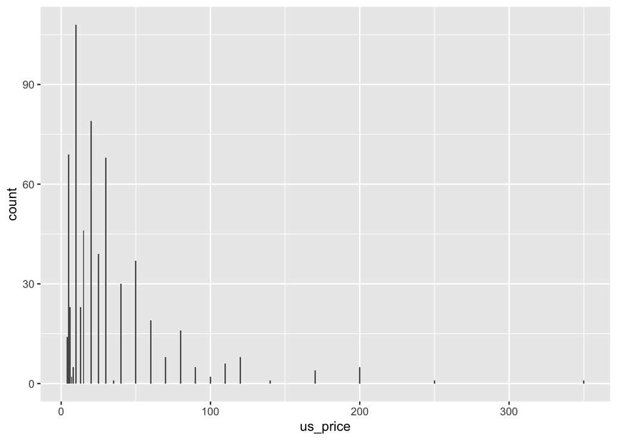

```r
ggplot(lego_sales, aes(us_price)) + geom_bar()
```

Using bar plot we found that the prices higher than 80 are less popular. So we limit the price from 0 to 80.

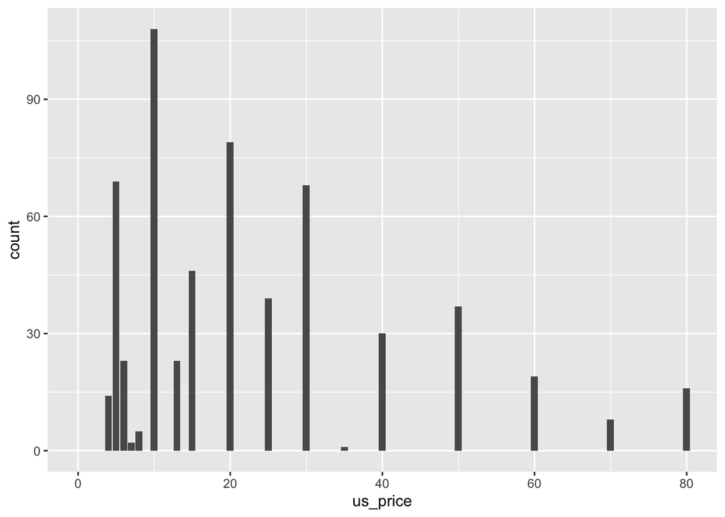

```r
ggplot(lego_sales, aes(us_price)) + geom_bar() + coord_cartesian(xlim = c(0, 80))
```

Now we found the price about 10 is most popular.